# Basic R Course SCC 2019

# Introduction

This course is targeted at complete R beginners.

It will cover basic R data structures like vector, list, factor and data.frame, explain the usage of external libraries and teach how to write simple function in R. In addition a first step into the R plotting system will be taken.

You will not be able to learn anything without training. After this course you will know basic concepts in R and will be able to work with data tables. But you will forget that soon if you do not use this knowledge at least once a week for about one year (wild guess).

So please dig into your own data as soon as possible. But not during the course!

# Basic data structures

R is a programming language. Therefore you need to store data in data structures that R can understand. And as data structures are an extremely boring thing without an example we might as well start getting an example dataset. Having completed the Unix course you should know what you are doing here. Start a Terminal and do this:

You all have taken the Unix course before and therefore this should look familiar. Do you remember where you need to paste that in?

```
if [ ! -d ~/NAS/git ]; then
   mkdir ~/NAS/git
fi
cd ~/NAS/git
git clone http://gitlab/stefanlang/R_usageTutorial_1.git
cd R_usageTutorial_1
R
```

Now you have a working R console. You can copy from this document that you also find in the R_usageTutorial_1/index.html using mouse select and middle mouse button insert.

You hopefully still remember the examples from the Unix course? Gtf files? Lets load one restricted to only ENSEMBL gene entries:

```r
genes <- read.delim( 'data/ENSEMBL_genes.gtf', header=F)
head(genes)
```

```
##     V1      V2   V3      V4      V5 V6 V7 V8
## 1 chr1 ENSEMBL gene 3102016 3102125  .  +  .
## 2 chr1 ENSEMBL gene 3783876 3783933  .  -  .
## 3 chr1 ENSEMBL gene 4529017 4529123  .  +  .
## 4 chr1 ENSEMBL gene 4723277 4723379  .  -  .
## 5 chr1 ENSEMBL gene 5644645 5644745  .  -  .
## 6 chr1 ENSEMBL gene 7265803 7265932  .  +  .
##                                                                                                                                                                                                             V9
## 1   gene_id ENSMUSG00000064842.1; transcript_id ENSMUSG00000064842.1; gene_type snRNA; gene_status KNOWN; gene_name Gm26206; transcript_type snRNA; transcript_status KNOWN; transcript_name Gm26206; level 3;
## 2   gene_id ENSMUSG00000088333.2; transcript_id ENSMUSG00000088333.2; gene_type snRNA; gene_status KNOWN; gene_name Gm27396; transcript_type snRNA; transcript_status KNOWN; transcript_name Gm27396; level 3;
## 3   gene_id ENSMUSG00000096126.1; transcript_id ENSMUSG00000096126.1; gene_type snRNA; gene_status KNOWN; gene_name Gm22307; transcript_type snRNA; transcript_status KNOWN; transcript_name Gm22307; level 3;
## 4   gene_id ENSMUSG00000088000.1; transcript_id ENSMUSG00000088000.1; gene_type snRNA; gene_status KNOWN; gene_name Gm25493; transcript_type snRNA; transcript_status KNOWN; transcript_name Gm25493; level 3;
## 5   gene_id ENSMUSG00000093015.1; transcript_id ENSMUSG00000093015.1; gene_type miRNA; gene_status KNOWN; gene_name Gm22463; transcript_type miRNA; transcript_status KNOWN; transcript_name Gm22463; level 3;
## 6 gene_id ENSMUSG00000077244.1; transcript_id ENSMUSG00000077244.1; gene_type snoRNA; gene_status KNOWN; gene_name Gm23274; transcript_type snoRNA; transcript_status KNOWN; transcript_name Gm23274; level 3;
```

OK - great! Learning about data types here - what did we get?

```r
class(genes)
```

```
## [1] "data.frame"
```

We will ignore most of the data.frame here, just one thing: You can get subsets of a table object (matrix, data.farme and others) by writing object_name[ rowID, colID] e.g genes[,1] to get the first column, genes[1:10,1] to get the first 10 values from column 1 and so on.

## Vector

We read an object of class ‘data.frame’. But I wanted to start with vectors. So lets get a vector of start positions from this data.frame object.

```r
vect = as.vector(genes[,4])
length(vect)
```

```
## [1] 13139
```

To be on the save side I have told R to take the 4th column of the data.table genes and convert it to a vector. I have saved the resulting vector with 13139 gene start positions into the variable ‘vect’. And we could create a histogram of all start positions:

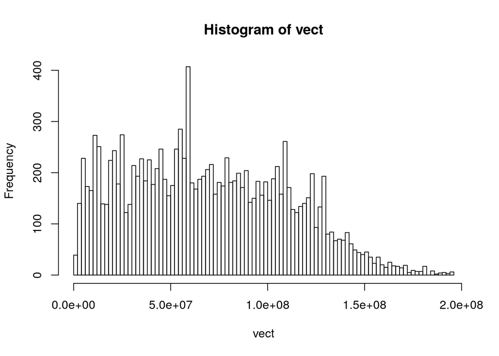

```r
hist(vect, breaks=100)
```

We now created a histogram of the start positions of all genes on all chromosomes. But this is misleading as we have the start positions of all genes in the genome relative to the chromosome. If we would like to visualize the start positions relative to the chromosomes we would need to split the start position into separate vectors for each chromosome.

## List

We need to store the start positions of a unknown amount of genes per chromosome, preferably in one object and not a long list of separate objects. I recommend to put all chromosome specific gene start positions into a new [R list object](http://www.r-tutor.com/r-introduction/list). A list in R can contain objects of any class and any size. Here we need to store the per chromosome start positions in the list. And there is a function to create this list in R: split().

```r
#get info about how to use the function split:
#?split

per_chr <- split( vect, as.vector( genes[,1]))
class(per_chr)
```

```
## [1] "list"
```

```r
names(per_chr)
```

```
##  [1] "chr1"  "chr10" "chr11" "chr12" "chr13" "chr14" "chr15" "chr16"
##  [9] "chr17" "chr18" "chr19" "chr2"  "chr3"  "chr4"  "chr5"  "chr6"
## [17] "chr7"  "chr8"  "chr9"  "chrM"  "chrX"  "chrY"
```

```r
lapply( per_chr, length)
```

```
## $chr1
## [1] 413
##
## $chr10
## [1] 810
##
## $chr11
## [1] 393
##
## $chr12
## [1] 744
##
## $chr13
## [1] 651
##
## $chr14
## [1] 786
##
## $chr15
## [1] 662
##
## $chr16
## [1] 481
##
## $chr17
## [1] 614
##
## $chr18
## [1] 478
##
## $chr19
## [1] 557
##
## $chr2
## [1] 547
##
## $chr3
## [1] 598
##
## $chr4
```

[output cut: 10 more lines]

```
##
## $chr8
## [1] 867
##
## $chr9
## [1] 898
##
## $chrM
## [1] 37
##
## $chrX
## [1] 405
##
## $chrY
## [1] 44
```

The function lapply does apply a R function (length) onto a R list (per_chr) and you see the result.

Now we can produce a histogram of all genes from chr1.

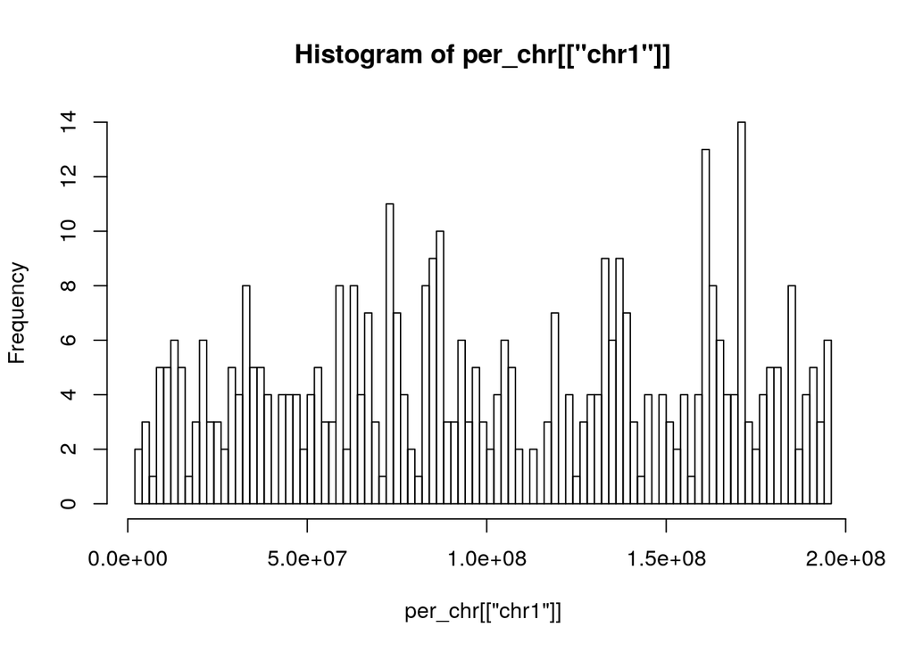

```r
hist( per_chr[['chr1']], breaks=100)
```

Here you learned about R lists and the functions split() and lapply().

## Factor

Factors are a huge source for problems in R. I have spend hours to look for errors in my scripts that ultimately boiled down that I was using a factor instead of a vector of strings. Therefore I want to go into details about factors:

Factors store a vector of integers (ids) and a string level for these. This level is what defines the ids on and if you use a factor in a numeric context the strings get replaced by the numeric position id of the string in the levels.

An example where you would probably expect a different order:

```r
newFactor <- factor( c('B','C','D','A','A','A','B'))
table(newFactor)
```

```
## newFactor
## A B C D
## 3 2 1 1
```

The newFactor is sorted in a lexical order, not in the order of appearance in the vector. That is sometimes good sometimes not what you expect. You can also force an order into a factor:

```r
states = factor( c('LT-HSC', 'ST-HSC', 'Early MPP', 'Late MPP') )
sort(states)
```

```
## [1] Early MPP Late MPP  LT-HSC    ST-HSC
## Levels: Early MPP Late MPP LT-HSC ST-HSC
```

```r
## Not what you want?
states = factor( c('LT-HSC', 'ST-HSC', 'Early MPP', 'Late MPP'), levels= c('LT-HSC', 'ST-HSC', 'Early MPP', 'Late MPP'))
sort(states)
```

```
## [1] LT-HSC    ST-HSC    Early MPP Late MPP
## Levels: LT-HSC ST-HSC Early MPP Late MPP
```

But adding something new to a factor is complicated - I normally re-create them.

```r
states[5] = 'LT-HSC'
## All OK ?
states
```

```
## [1] LT-HSC    ST-HSC    Early MPP Late MPP  LT-HSC
## Levels: LT-HSC ST-HSC Early MPP Late MPP
```

```r
states[5] = 'CLP'
states
```

```
## [1] LT-HSC    ST-HSC    Early MPP Late MPP  <NA>
## Levels: LT-HSC ST-HSC Early MPP Late MPP
```

The fifth element is ‘NA’ instead of ‘CLP’. To add the ‘CLP’ into your factor you need to re-create it:

```r
states = factor( c('LT-HSC', 'ST-HSC', 'Early MPP', 'Late MPP', 'CLP') , levels=c('LT-HSC', 'ST-HSC', 'Early MPP', 'Late MPP', 'CLP') )
states
```

```
## [1] LT-HSC    ST-HSC    Early MPP Late MPP  CLP
## Levels: LT-HSC ST-HSC Early MPP Late MPP CLP
```

### Where do you find factors in real live?

The chromosome information in the genes data.frame is a factor. Try to re-order it.

Better break that up into more steps:

```r
## get the old factor as vector
Strings = as.vector(genes[,1])
old_levels = levels(genes[,1])
old_levels
```

```
##  [1] "chr1"  "chr10" "chr11" "chr12" "chr13" "chr14" "chr15" "chr16"
##  [9] "chr17" "chr18" "chr19" "chr2"  "chr3"  "chr4"  "chr5"  "chr6"
## [17] "chr7"  "chr8"  "chr9"  "chrM"  "chrX"  "chrY"
```

```r
## for the lacy ones
paste ( old_levels, collapse="', '" )
```

```
## [1] "chr1', 'chr10', 'chr11', 'chr12', 'chr13', 'chr14', 'chr15', 'chr16', 'chr17', 'chr18', 'chr19', 'chr2', 'chr3', 'chr4', 'chr5', 'chr6', 'chr7', 'chr8', 'chr9', 'chrM', 'chrX', 'chrY"
```

You the can simply copy the old order into your script using copy paste:

```r
reordered = c( 'chr1', 'chr10', 'chr11', 'chr12', 'chr13', 'chr14', 'chr15', 'chr16',
        'chr17', 'chr18', 'chr19', 'chr2', 'chr3', 'chr4', 'chr5', 'chr6', 'chr7',
        'chr8', 'chr9', 'chrM', 'chrX', 'chrY')

reordered = c( 'chr1', 'chr2', 'chr3', 'chr4', 'chr5', 'chr6', 'chr7',
        'chr8', 'chr9','chr10', 'chr11', 'chr12', 'chr13', 'chr14', 'chr15', 'chr16',
        'chr17', 'chr18', 'chr19', 'chrX', 'chrY',  'chrM')
## now we can re-create the factor in the table:
genes[,1] <- factor(Strings, levels= reordered )

table(genes[,1])
```

```
##
##  chr1  chr2  chr3  chr4  chr5  chr6  chr7  chr8  chr9 chr10 chr11 chr12
##   413   547   598   423   698   783  1250   867   898   810   393   744
## chr13 chr14 chr15 chr16 chr17 chr18 chr19  chrX  chrY  chrM
##   651   786   662   481   614   478   557   405    44    37
```

And this new order would also be used in the split call we used previously:

```r
per_chr <- split( vect, genes[,1] )
class(per_chr)
```

```
## [1] "list"
```

```r
names(per_chr)
```

```
##  [1] "chr1"  "chr2"  "chr3"  "chr4"  "chr5"  "chr6"  "chr7"  "chr8"
##  [9] "chr9"  "chr10" "chr11" "chr12" "chr13" "chr14" "chr15" "chr16"
## [17] "chr17" "chr18" "chr19" "chrX"  "chrY"  "chrM"
```

### What you learned

Factors in R are more rigid objects that vectors; you can not just add a new entry into a factor as it will get the ‘NA’ value. Instead I recommend to re-create a factor if you add a new element.

# R functions

R function are quite simple; you can store a function into a object as you can store a vector into a object:

```r
vect <- c(1,3,4,5,7)
funct <- function(x) { x * 100 }
funct(vect)
```

```
## [1] 100 300 400 500 700
```

A R function will always return what is written in the last line of the function definition.

## Example 1: get genes in chromosomal area

Lets re-do the Unix course example: Get all genes in the chromosomal area chr4:10000002-19000002.

I do recommend, that you NEVER use a object inside a function that you do not get as a function option (function(“This part here”)). Using objects defined outside the function can lead to unexpected results if you change the outside object and then re-run the function.

```r
getGenes <- function( tab, chr, start, end ) {

}
```

**Can you fill the logics?** Hint: you need a ‘for loop’ to process the tab object row by row, and I recommend to just obtain the row ids that match in the first step. It is easier to return a subset of the table using the tab[ids,] method in the end of the function.

```r
getGenes <- function( tab, chr, start, end ) {
    ids = NULL
    for (id in 1:nrow(tab) ) {
        if ( tab[id,1] == chr && tab[id,3] == 'gene' && tab[id,4] < end && tab[id,5] > start ) {
            ids <- c( ids, id)
        }
    }
    if ( length(ids) > 0 ){
        tab[ids,]
    }else {
        NULL
    }
}

chr4_10000002_19000002 <- getGenes( genes, 'chr4', 10000002, 19000002 )
```

## Example 2: extract specific information from the 9th column

A lot of the gtf information is merged into the 9th column of the gtf file. It would be good to get a function that is extracting any information out of that column.

For this function you need a string handling R package that is not loaded by default: stringr.

Load this package into your R session like this:

```r
library(stringr)
```

The important function here is [str_extract](https://stringr.tidyverse.org/articles/regular-expressions.html) and especially the regular expression part. We will have strings like

```
"gene_id ENSMUSG00000088333.2; transcript_id ENSMUSG00000088333.2; gene_type snRNA; gene_status KNOWN; gene_name Gm27396; transcript_type snRNA; transcript_status KNOWN; transcript_name Gm27396; level 3;"
```

where we need to extract e.g. the “gene_name Gm27396” or even better the ‘Gm27396’ part.

The easiest and least problematic is to first str_extract the whole entry “gene_name Gm27396”, str_split that based on whitespace and return the second entry.

```r
whole_entry = str_extract( genes[1,9], "gene_name \\w*" )
whole_entry
```

```
## [1] "gene_name Gm26206"
```

```r
split =str_split(whole_entry, "\\s+" )
class(split)
```

```
## [1] "list"
```

```r
split[[1]][2]
```

```
## [1] "Gm26206"
```

```r
## or in one line
str_split(str_extract( genes[1,9], "gene_name \\w*") , "\\s+" )[[1]][2]
```

```
## [1] "Gm26206"
```

```r
## And what if the string does not contain the information
str_split(str_extract( "Not including the information" , "gene_name \\w*") , "\\s+" )[[1]][2]
```

```
## [1] NA
```

I am deeply impressed if you managed to extract the information from the string by just googling and without the help.

Now we know how to extract this information from one string. But we want to do this for all rows in the genes table. And we of cause do not only want to extract ‘gene_name’ but also any of the other information tags.

The function would look like that, just that this one is full of errors:

```r
getGtfInfo = function( tab, info='gene_name' ) {
    info = vector( 'character', nrow(tab) )
    for (id in 1:now(tab) ) {
        info[id] = str_split(str_extract( genes[1,9], "gene_name \\w*") , "\\s+" )[[1]][2]
    }
    info
}
```

Please correct the errors! Hint - info is not used at all and do we really want to use genes[1,9]?

Test your function using the chr4_10000002_19000002 from the last section. Can you select the ‘gene_id’ elements?

```r
getGtfInfo = function( tab, info='gene_name' ) {
    ret = vector( 'character', nrow(tab) ) ## info is already used!
    for (id in 1:nrow(tab) ) {
        ret[id] = str_split(str_extract( tab[id,9], paste( info,"[\\w-]*") ) , "\\s+" )[[1]][2]
        ## genes[1,9] is (1) an outside object and (2) not iterated over using id
        ## and we need to include - in the [\\w-] regexp - see row 8
    }
    ret
}

getGtfInfo( chr4_10000002_19000002, 'gene_name' )
```

```
##  [1] "Mir3471-1" "Gm22940"   "Gm26663"   "Gm22477"   "Gm25002"
##  [6] "Gm10604"   "Gm26895"   "n-R5s182"  "Gm26250"   "Gm23162"
## [11] "Gm24068"   "Gm24908"   "Gm24317"   "Gm24567"   "Gm26148"
## [16] "Mir6400"   "Gm22690"   "Gm24978"   "Gm23975"   "Gm23384"
## [21] "Gm25971"   "Gm24419"
```

```r
getGtfInfo( chr4_10000002_19000002, 'gene_id' )
```

```
##  [1] "ENSMUSG00000092880" "ENSMUSG00000089185" "ENSMUSG00000097019"
##  [4] "ENSMUSG00000084518" "ENSMUSG00000080663" "ENSMUSG00000073995"
##  [7] "ENSMUSG00000097459" "ENSMUSG00000065823" "ENSMUSG00000080359"
## [10] "ENSMUSG00000092822" "ENSMUSG00000077701" "ENSMUSG00000087919"
## [13] "ENSMUSG00000096738" "ENSMUSG00000094515" "ENSMUSG00000088055"
## [16] "ENSMUSG00000098929" "ENSMUSG00000092795" "ENSMUSG00000096423"
## [19] "ENSMUSG00000064619" "ENSMUSG00000089218" "ENSMUSG00000089578"
## [22] "ENSMUSG00000088500"
```

## What you learned

- Load an external package (stringr) and use functions that are defined in that package.
- Create R functions
- Iterate over tables
- Extract strings based on a regular expression

# Creating data plots

You have already seen the most straight forward R plotting using the hist() function earlier. And for a start this type of plot (vs. ggplot2 or plotly) is the one I prefere for this tutorial.

I am using about 3-5 types of plots: [normal xy](https://www.statmethods.net/graphs/scatterplot.html) which are so simple you can read up on them yourself, [more intersting boxplots](https://www.statmethods.net/graphs/boxplot.html), [violin plots](https://www.r-graph-gallery.com/violin-plot/) and the most important heatmaps.

There are many ways to produce heatmaps in R. I want to focus on heatmap3 which is not the most fany one any more, but is still working fine for my needs.

But first lets get a dataset we can plot from. I have choosen from a recent publication Differences in Cell Cycle Status Underlie Transcriptional Heterogeneity in the HSC Compartment - mainly due to personal interest. I have downloaded the data and put it into the git data folder.

```r
dat <- read.delim('data/GSE108155_Bulk_limma.csv', sep="\t")

## some of the gene names are not unique - just paste a _1 _2 ... _n to all additional ones
forceAbsoluteUniqueSample = function( x ,separator='_') {
 last = ''
 ret <- vector(length=length(x))
 for ( i in 1:length(x) ){
    if ( is.null(ret) ){
        last = x[i]
        ret[i] <- last
    }
    else{
        last = x[i]
        if ( ! is.na(match( last, ret )) ){
            last <- paste(last,separator,sum( ! is.na(match( x[1:i], last )))-1, sep = '')
        }
        ret[i] <- last
    }
 }
 ret
}

expr <- dat[,1:12]
rownames(expr) <- forceAbsoluteUniqueSample(as.character(dat[,'ID']))

GOI <- as.vector(dat[order( dat[,'adj.P.Val_high_vs_int'][1:20] ),'ID'])

m = match( GOI, rownames(expr))

## Did we misspell a gene?
GOI[which(is.na(m))] # this should always be tried!
```

```
## character(0)
```

```r
forPlot <- expr[m,]
dim(forPlot)
```

```
## [1] 20 12
```

## Heatmap using heatmap.3

Heatmap.3 is a special heatmap function that allows row and cloumn color bars and many other features. If you enver got a heatmap from me it has been produced using this function.

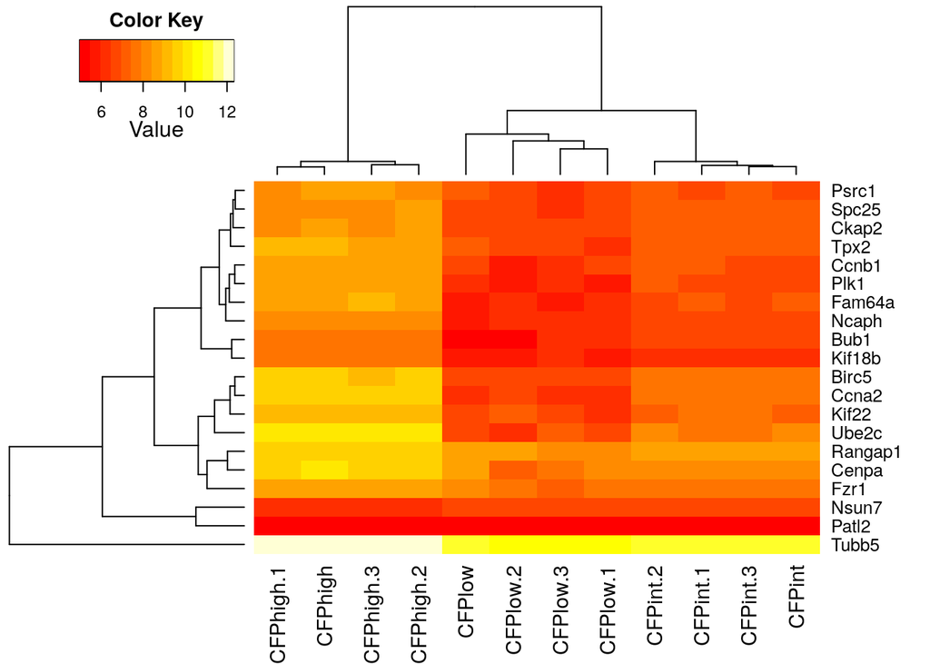

```r
source( 'data/heatmap.3.R' )

heatmap.3( as.matrix(forPlot), ColSideColors=NULL, RowSideColors=NULL  )
```

But can we get the bluered colors into the plot?

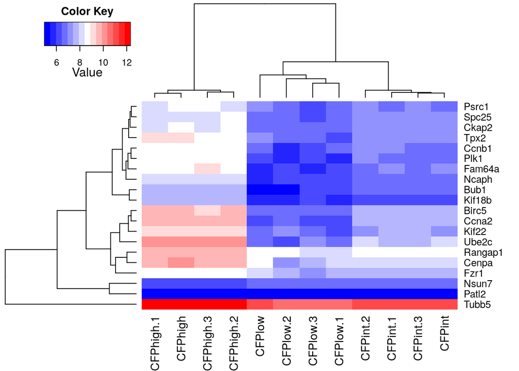

```r
library(gplots)

heatmap.3( as.matrix(forPlot), ColSideColors=NULL, RowSideColors=NULL, col= bluered )
```

You can play with the colors using any color function e.g. rainbow, greenred, redgreen or simply colorpanel.

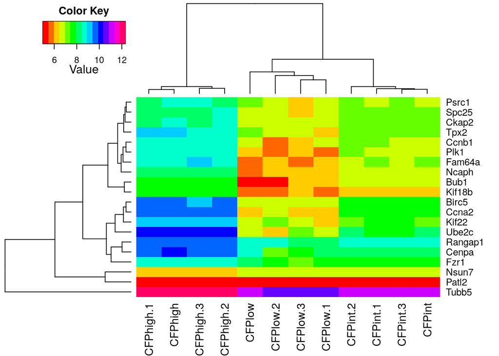

```r
heatmap.3( as.matrix(forPlot), ColSideColors=NULL, RowSideColors=NULL, col= rainbow )
```

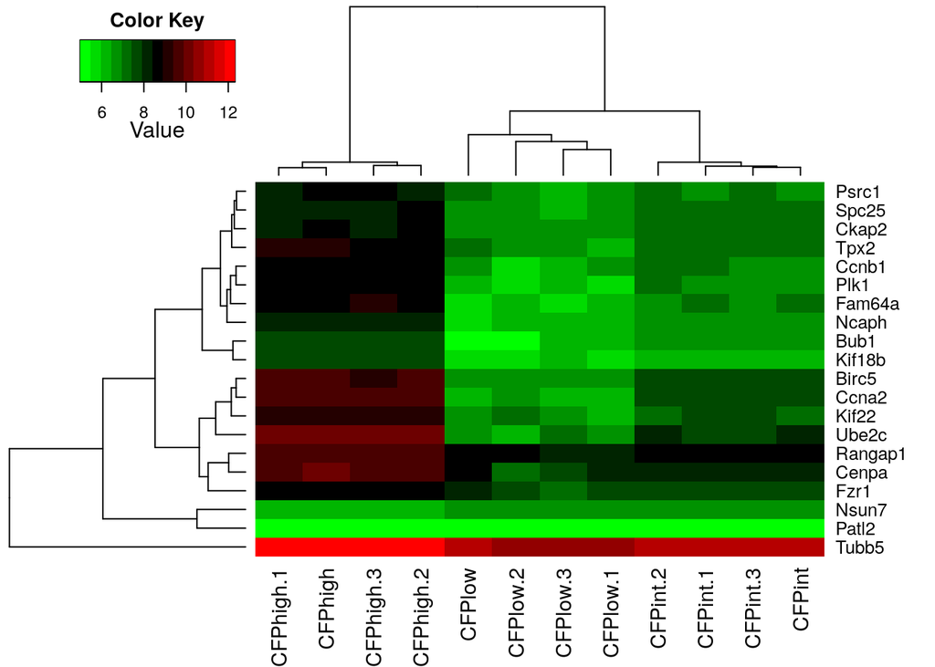

```r
heatmap.3( as.matrix(forPlot), ColSideColors=NULL, RowSideColors=NULL, col=  greenred)
```

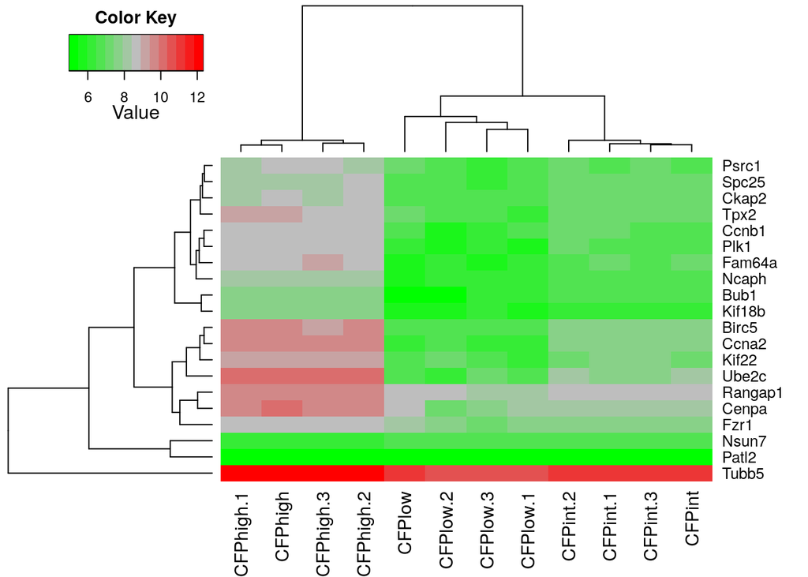

```r
heatmap.3( as.matrix(forPlot), ColSideColors=NULL, RowSideColors=NULL, col= function(x) { colorpanel( x,'green', 'gray',  'red')})
```

I have created a function around heatmap.3 to reduce the function I need to remember. You can look into that on [my github page](https://github.com/stela2502/BioData/blob/master/R/complexHeatmap.R)